# Practica2_NicoloTrevisani

## Minería de Datos (Master en Data Science, UIMP-UC)

## Tarea 2. Problemas de Clasificación - Reducción de la Dimensión

### [Profesores: Steven Van Vaerenbergh, Rodrigo G. Manzanas, Joaquín Bedia y Sixto Herrera]

### Estudiante: Nicolò Trevisani

En la presente tarea consideraremos el dataset `meteo.csv`, que podéis descargaros en el GitHub dedicado a este Máster ([meteo.csv](https://github.com/SantanderMetGroup/Master-Data-Science/blob/master/Data_mining/datasets/meteo.csv.)) y que ha sido utilizado en diferentes sesiones prácticas. Dicho dataset contiene en la primera columna el valor de precipitación observado en Lisboa en el periodo 1979-2008 mientras que en las restantes contiene los valores observados de diferentes variables atmosféricas en 40 puntos que cubren aproximadamente la Península Ibérica. Dichas variables serán los `predictores` del modelo mientras que la precipitación será nuestra variable objetivo. En particular los predictores son:

- Altura geopotencial en 500 hPa (columnas 2:41),
- Temperatura del aire en 850 hPa (columnas 42:81), 700 hPa (columnas 82:121) y 500 hPa (columnas 122:161),
- Temperatura del aire en superficie (columnas 162:201),
- Humedad específica del aire en 850 hPa (columnas 202:241) y 500 hPa (columnas 242:281) y
- Presión al nivel del mar (columnas 282:321)

Para establecer el problema de clasificación consideraremos dos umbrales de discretización, 1 mm y 20 mm, que definen la ocurrencia de precipitación (Wet days) y de precipitaciones intensas (Very heavy precipitation days), respectivamente. Puedes consultar más detalles de la definición en la web de [ECA&D](https://www.ecad.eu//indicesextremes/indicesdictionary.php).

Para el desarrollo de la tarea se permitirá el uso de todo el material incluido en el Moodle de las asignatura así como el desarrollado por el alumno durante la realización de las prácticas.

La entrega consisitirá de un notebook de Jupyter ó un R-MarkDown, junto con el archivo html que éste genera. Ambos ficheros se entregarán a través del Moodle de la asignatura en la tarea correspondiente.

### Punto 1 (3 puntos):

En esta primera parte de la tarea trataremos de ilustrar parte de los problemas reflejados en las sesiones teórico-prácticas planteando diferentes experimentos con el dataset `meteo.csv`. En primer lugar, considerar el dataset completo incluyendo tanto las variables predictoras como la variable objetivo. Por un lado, calculad las componentes principales con y sin estandarización (`Nota:` consultar la ayuda de la función scale -> `? scale`):

- ¿Cómo contribuye en cada caso la variable objetivo a la primera componente principal?
- ¿A qué componente principal contribuye principalmente la variable objetivo? ¿qué porcentaje de varianza se explica hasta dicha componente?
- En base a los puntos anteriores, ¿puede considerarse en alguno de los casos que la variable objetivo se "eliminaría" del modelo debido a su contribución a cada una de las componentes principales?
- ¿Cómo se distribuye la contribución de las diferentes variables del espacio original a la primera componente principal? En caso de no estandarizar, ¿puede inferirse alguna relación entre el rango de las variables y su contribución a la primera componente principal?

`Nota 1:` en principio es posible trabajar con el dataset completo sin seleccionar un subconjunto pero si surge algún problema de memoria podéis considerar únicamente los primeros 10 años (~3650 filas).

`Nota 2:` usad las herramientas gráficas vistas durante la práctica para ilustrar los resultados y las conclusiones obtenidas.

## Desarrollo Punto 1

```r
# Cargo el dataset
meteo <- read.csv("meteo.csv", row.name = 1)
```

```r
# Pinto las primeras lineas
head(meteo)
```

A data.frame: 6 × 321

|  | y <dbl> | X1 <dbl> | X2 <dbl> | X3 <dbl> | X4 <dbl> | X5 <dbl> | X6 <dbl> | X7 <dbl> | X8 <dbl> | X9 <dbl> | ⋯ | X311 <dbl> | X312 <dbl> | X313 <dbl> | X314 <dbl> | X315 <dbl> | X316 <dbl> | X317 <dbl> | X318 <dbl> | X319 <dbl> | X320 <dbl> |
| --- | --- | --- | --- | --- | --- | --- | --- | --- | --- | --- | --- | --- | --- | --- | --- | --- | --- | --- | --- | --- | --- |
| 1 | 10.9 | 57042.96 | 56534.84 | 55884.40 | 55175.59 | 54458.21 | 56980.27 | 56460.59 | 55800.02 | 55051.15 | ⋯ | 101985.9 | 101627.3 | 101357.2 | 101110.7 | 101291.0 | 101814.9 | 101479.4 | 101164.5 | 100970.7 | 100905.3 |
| 2 | 0.6 | 56963.20 | 56493.45 | 55930.82 | 55340.20 | 54768.63 | 56856.57 | 56361.95 | 55776.76 | 55164.26 | ⋯ | 102048.1 | 102069.7 | 102204.5 | 102480.3 | 102858.8 | 101973.3 | 102033.3 | 102165.5 | 102323.9 | 102534.2 |
| 3 | 13.0 | 56522.59 | 55971.40 | 55304.34 | 54498.03 | 53725.15 | 56514.84 | 55977.71 | 55327.28 | 54569.78 | ⋯ | 102399.1 | 102448.4 | 102438.3 | 102434.3 | 102339.8 | 102669.7 | 102565.5 | 102530.3 | 102453.6 | 102487.1 |
| 4 | 0.0 | 54627.98 | 53979.80 | 53494.05 | 53072.98 | 52616.36 | 54776.17 | 54089.05 | 53516.98 | 53012.86 | ⋯ | 100970.0 | 100672.8 | 100360.7 | 100133.7 | 100028.4 | 101126.2 | 100700.0 | 100381.3 | 100118.3 | 100319.8 |
| 5 | 0.0 | 53584.38 | 53391.01 | 53310.38 | 53292.82 | 53340.13 | 53781.70 | 53498.13 | 53306.82 | 53213.26 | ⋯ | 100652.7 | 100663.5 | 100747.7 | 100934.0 | 101015.8 | 100801.6 | 100685.3 | 100777.5 | 100909.4 | 101164.7 |
| 6 | 1.2 | 54221.86 | 54220.24 | 54328.55 | 54772.49 | 55251.11 | 54391.11 | 54345.93 | 54284.05 | 54525.99 | ⋯ | 101358.6 | 101511.5 | 101798.9 | 102142.2 | 102368.5 | 101438.7 | 101440.9 | 101685.3 | 102030.7 | 102311.9 |

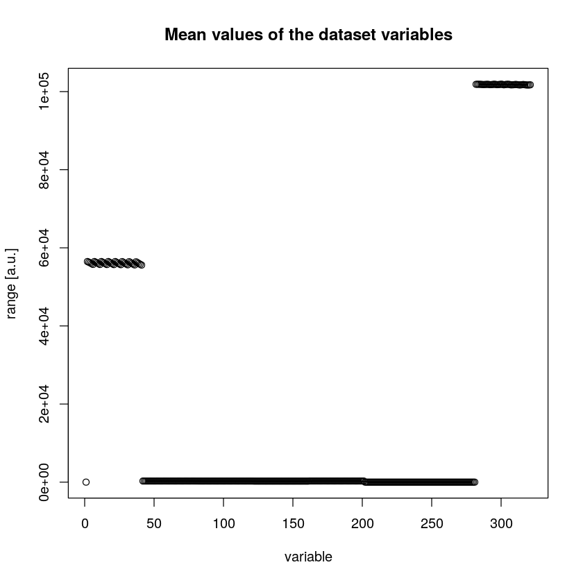

```r
# Miro el rango de las variables
plot(1:321,apply(meteo,2,mean),
    xlab = "variable",
    ylab = "range [a.u.]",
    main = "Mean values of the dataset variables")
```

Cargo las librerias necesarias para hacer una *principal component analysis*

```r
# Load the libraries for PCA
library("FactoMineR")
library("factoextra")
```

### Saco las componentes principales, sin escalar las variables e incluiendo la variable objetivo

```r
# Busco las componentes principales
meteo.pca <- prcomp(meteo)
```

```r
# Pinto la varianza explicada por cada componente
eigenvalues <- get_eig(meteo.pca)
eigenvalues
```

A data.frame: 321 × 3

|  | eigenvalue <dbl> | variance.percent <dbl> | cumulative.variance.percent <dbl> |
| --- | --- | --- | --- |
| Dim.1 | 55659101,935 | 71,628313979 | 71,62831 |
| Dim.2 | 13791779,837 | 17,748794036 | 89,37711 |
| Dim.3 | 3463992,284 | 4,457849989 | 93,83496 |
| Dim.4 | 2556212,925 | 3,289618690 | 97,12458 |
| Dim.5 | 795215,893 | 1,023372129 | 98,14795 |
| Dim.6 | 562330,224 | 0,723668986 | 98,87162 |
| Dim.7 | 216368,035 | 0,278446418 | 99,15006 |
| Dim.8 | 167058,031 | 0,214988828 | 99,36505 |
| Dim.9 | 114481,672 | 0,147327730 | 99,51238 |
| Dim.10 | 80844,689 | 0,104039924 | 99,61642 |
| Dim.11 | 64776,651 | 0,083361789 | 99,69978 |
| Dim.12 | 47896,531 | 0,061638576 | 99,76142 |
| Dim.13 | 32306,225 | 0,041575238 | 99,80300 |
| Dim.14 | 23963,935 | 0,030839453 | 99,83384 |
| Dim.15 | 21544,806 | 0,027726250 | 99,86156 |
| Dim.16 | 16510,886 | 0,021248041 | 99,88281 |
| Dim.17 | 14052,252 | 0,018083999 | 99,90089 |
| Dim.18 | 10683,850 | 0,013749165 | 99,91464 |
| Dim.19 | 9087,546 | 0,011694863 | 99,92634 |
| Dim.20 | 6907,946 | 0,008889913 | 99,93523 |
| Dim.21 | 5807,443 | 0,007473662 | 99,94270 |
| Dim.22 | 5202,738 | 0,006695461 | 99,94940 |
| Dim.23 | 4655,168 | 0,005990788 | 99,95539 |
| Dim.24 | 3853,888 | 0,004959611 | 99,96035 |
| Dim.25 | 3434,929 | 0,004420448 | 99,96477 |
| Dim.26 | 2765,375 | 0,003558791 | 99,96833 |
| Dim.27 | 2528,887 | 0,003254453 | 99,97158 |
| Dim.28 | 2303,165 | 0,002963968 | 99,97455 |
| Dim.29 | 2088,545 | 0,002687772 | 99,97723 |
| Dim.30 | 1819,784 | 0,002341901 | 99,97957 |
| ⋮ | ⋮ | ⋮ | ⋮ |
| Dim.292 | 4,244196e-08 | 5,461902e-14 | 100 |
| Dim.293 | 3,641570e-08 | 4,686377e-14 | 100 |
| Dim.294 | 3,514806e-08 | 4,523243e-14 | 100 |
| Dim.295 | 3,032770e-08 | 3,902905e-14 | 100 |
| Dim.296 | 2,765816e-08 | 3,559359e-14 | 100 |
| Dim.297 | 2,477463e-08 | 3,188275e-14 | 100 |
| Dim.298 | 2,240824e-08 | 2,883742e-14 | 100 |
| Dim.299 | 1,937194e-08 | 2,492997e-14 | 100 |
| Dim.300 | 1,860904e-08 | 2,394818e-14 | 100 |
| Dim.301 | 1,738441e-08 | 2,237220e-14 | 100 |
| Dim.302 | 1,352055e-08 | 1,739974e-14 | 100 |
| Dim.303 | 1,166541e-08 | 1,501235e-14 | 100 |
| Dim.304 | 1,006419e-08 | 1,295171e-14 | 100 |
| Dim.305 | 9,479774e-09 | 1,219963e-14 | 100 |
| Dim.306 | 8,325833e-09 | 1,071461e-14 | 100 |
| Dim.307 | 7,468414e-09 | 9,611185e-15 | 100 |
| Dim.308 | 6,190183e-09 | 7,966215e-15 | 100 |
| Dim.309 | 5,507153e-09 | 7,087217e-15 | 100 |
| Dim.310 | 5,209113e-09 | 6,703666e-15 | 100 |
| Dim.311 | 4,365591e-09 | 5,618127e-15 | 100 |
| Dim.312 | 4,018178e-09 | 5,171037e-15 | 100 |
| Dim.313 | 3,464708e-09 | 4,458772e-15 | 100 |
| Dim.314 | 3,190513e-09 | 4,105907e-15 | 100 |
| Dim.315 | 3,003470e-09 | 3,865199e-15 | 100 |
| Dim.316 | 2,683200e-09 | 3,453039e-15 | 100 |
| Dim.317 | 2,441389e-09 | 3,141850e-15 | 100 |
| Dim.318 | 2,161904e-09 | 2,782179e-15 | 100 |
| Dim.319 | 1,933186e-09 | 2,487839e-15 | 100 |
| Dim.320 | 1,628942e-09 | 2,096303e-15 | 100 |
| Dim.321 | 1,338003e-09 | 1,721890e-15 | 100 |

```r
# Pinto la composición de cada componente principal
# en terminos de las variables
meteo.var <- get_pca(meteo.pca)
head(meteo.var$contrib)
```

A matrix: 6 × 321 of type dbl

|  | Dim.1 | Dim.2 | Dim.3 | Dim.4 | Dim.5 | Dim.6 | Dim.7 | Dim.8 | Dim.9 | Dim.10 | ⋯ | Dim.312 | Dim.313 | Dim.314 | Dim.315 | Dim.316 | Dim.317 | Dim.318 | Dim.319 | Dim.320 | Dim.321 |
| --- | --- | --- | --- | --- | --- | --- | --- | --- | --- | --- | --- | --- | --- | --- | --- | --- | --- | --- | --- | --- | --- |
| y | 4,973872e-06 | 9,394439e-06 | 4,500889e-05 | 2,475052e-05 | 0,0002638008 | 0,0001797239 | 3,452958e-07 | 3,110981e-06 | 0,0002288954 | 0,0002179048 | ⋯ | 1,563441e-13 | 9,630988e-13 | 5,949008e-14 | 3,278221e-13 | 1,621025e-12 | 4,643880e-13 | 1,208670e-12 | 2,243267e-12 | 7,151822e-13 | 9,257767e-14 |
| X1 | 1,575959e+00 | 1,954718e-02 | 5,187316e+00 | 1,742858e+00 | 0,3372862563 | 0,7333849035 | 1,015937e+01 | 1,651255e+00 | 2,6477191023 | 0,0045715346 | ⋯ | 1,205802e-11 | 7,266243e-12 | 1,896551e-12 | 1,109885e-12 | 3,517749e-13 | 1,384201e-13 | 4,596566e-13 | 5,421356e-13 | 2,547923e-13 | 5,530746e-14 |
| X2 | 1,849147e+00 | 2,002132e-02 | 5,540281e+00 | 4,663866e-01 | 0,3681753155 | 0,5076607532 | 5,229383e+00 | 3,732499e+00 | 0,3267360261 | 0,0531303749 | ⋯ | 1,425169e-11 | 1,450981e-11 | 8,665231e-12 | 7,902516e-14 | 1,780901e-12 | 1,747815e-12 | 1,609144e-12 | 1,402177e-12 | 1,021913e-12 | 3,806073e-14 |
| X3 | 2,082654e+00 | 1,636389e-01 | 5,051342e+00 | 8,268331e-02 | 0,2226894136 | 0,2444250450 | 5,409152e-01 | 6,128738e+00 | 2,8484246283 | 0,0770786730 | ⋯ | 1,904859e-12 | 4,651322e-13 | 8,448678e-12 | 3,543296e-13 | 8,161572e-12 | 6,259289e-13 | 3,825545e-13 | 1,873417e-12 | 4,492359e-12 | 5,159071e-14 |
| X4 | 2,228396e+00 | 3,901357e-01 | 3,922891e+00 | 2,179590e+00 | 0,0212708709 | 0,0584795788 | 9,593101e-01 | 7,696449e+00 | 0,8616052273 | 0,0344009966 | ⋯ | 1,507426e-12 | 6,579486e-12 | 1,335470e-11 | 9,753866e-14 | 9,250501e-13 | 1,294426e-12 | 2,503759e-13 | 2,706215e-12 | 4,674348e-12 | 5,837660e-13 |
| X5 | 2,247589e+00 | 6,069066e-01 | 2,560462e+00 | 7,461982e+00 | 0,1154593107 | 0,0082278691 | 5,335626e+00 | 7,653079e+00 | 2,5624429968 | 0,0001027591 | ⋯ | 1,995035e-13 | 1,684167e-12 | 9,125399e-12 | 2,313223e-17 | 1,281782e-13 | 1,260457e-12 | 1,975592e-12 | 5,877210e-13 | 2,106373e-12 | 2,401036e-13 |

```r
# Contribución de la variable objetivo a la primera componente principal
print(paste("La contribución de la variable objetivo a la primera componente principal es:",
            format(round(meteo.var$contrib[1,1],6), nsmall = 6)))
```

```
[1] "La contribución de la variable objetivo a la primera componente principal es: 5e-06"
```

```r
# Componente principal que recibe la contribución máxima de
# la variable objetivo

best.contrib <- which(meteo.var$contrib[1,] == max(meteo.var$contrib[1,]))

print(paste("La contribución máxima de la variable objetivo es a la componente principal",
            best.contrib,
            ". Hasta dicha componente principal se explica el",
            format(round(eigenvalues$cumulative.variance.percent[best.contrib],4), nsmall = 2),"%",
           "de la varianza"))
```

```
[1] "La contribución máxima de la variable objetivo es a la componente principal 74 . Hasta dicha componente principal se explica el 99,9997 % de la varianza"
```

Considerando los resultados de las dos celdas anteriores, parece que la variable objetivo no es capaz de explicar practicamente nada de la varianza del dataset, y podría ser descartada.

Eso parece un artifacto debido a que las variables no han sido normalizadas y por eso el metodo PCA asigna gran importancia a variables con rangos elevados:

- alturas (~$10^4$ m);
- presiones (~$10^4$ Pa)

Prefieriendolas a variables como la cantidad de lluvia cuyo rango es de ~$10^0$ mm.

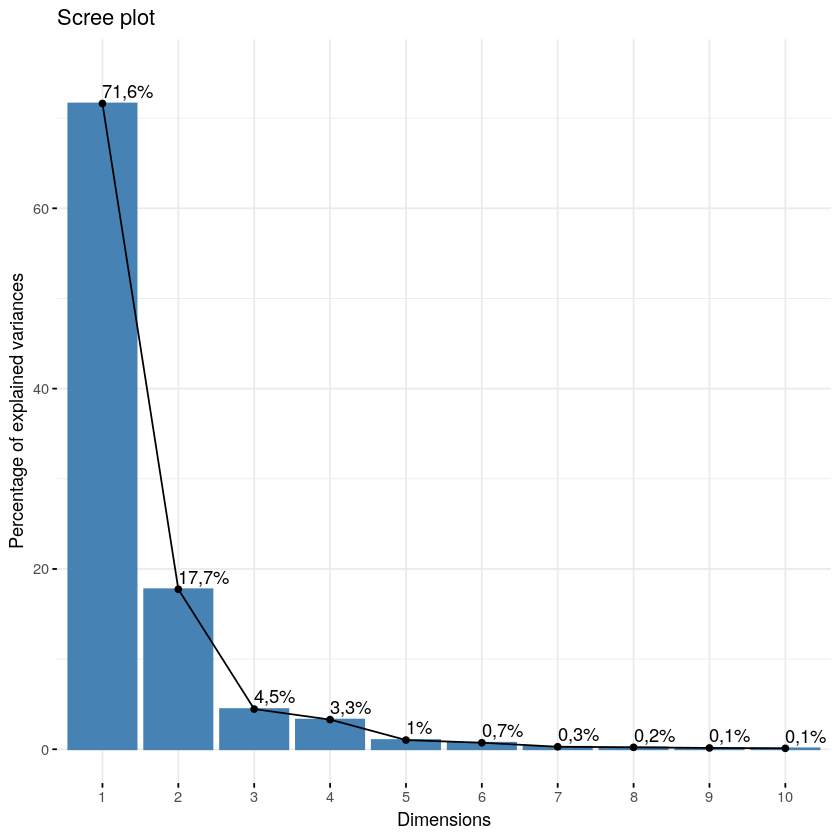

```r
# Plot del porcentage de varianza explicado por cada una de
# las primeras 10 componentes principales
fviz_screeplot(meteo.pca, addlabels = TRUE, ylim = c(0, 75))
```

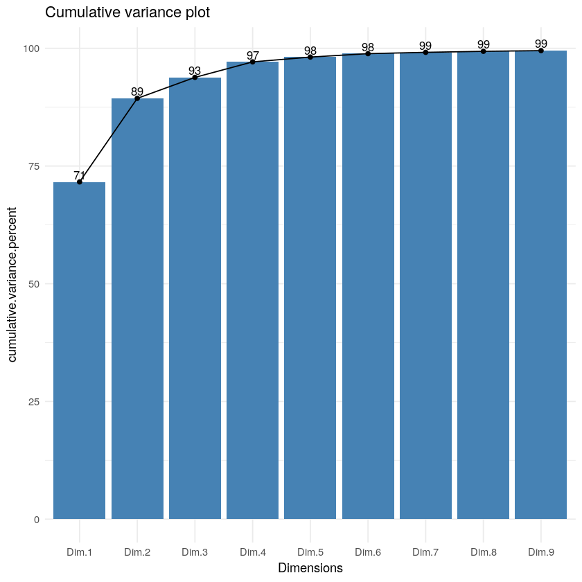

```r
# Plot del porcentage de varianza cumulada explicado por
# las primeras 9 componentes principales

plot.eigenvalues <- eigenvalues[1:9,]
plot.eigenvalues$Dimensions <- row.names(plot.eigenvalues)

ggplot(data=plot.eigenvalues, aes(x=Dimensions, y = cumulative.variance.percent, group=1)) +
        geom_bar(stat="identity", fill="steelblue") +
        geom_text(aes(label=floor(cumulative.variance.percent)), vjust=-0.3, size=3.5) +
        geom_line(color="black") +
        geom_point() +
        ggtitle("Cumulative variance plot") +
        theme_minimal()
```

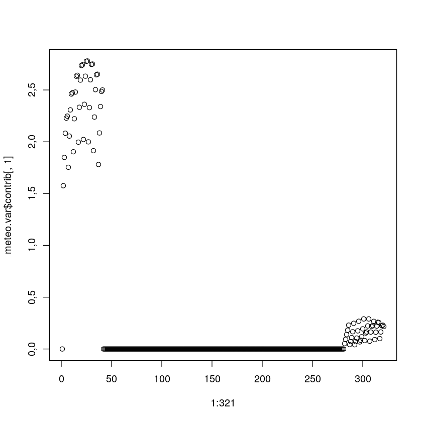

```r
# Contribución de cada variable a la primera componente principal
plot(1:321,meteo.var$contrib[,1])
```

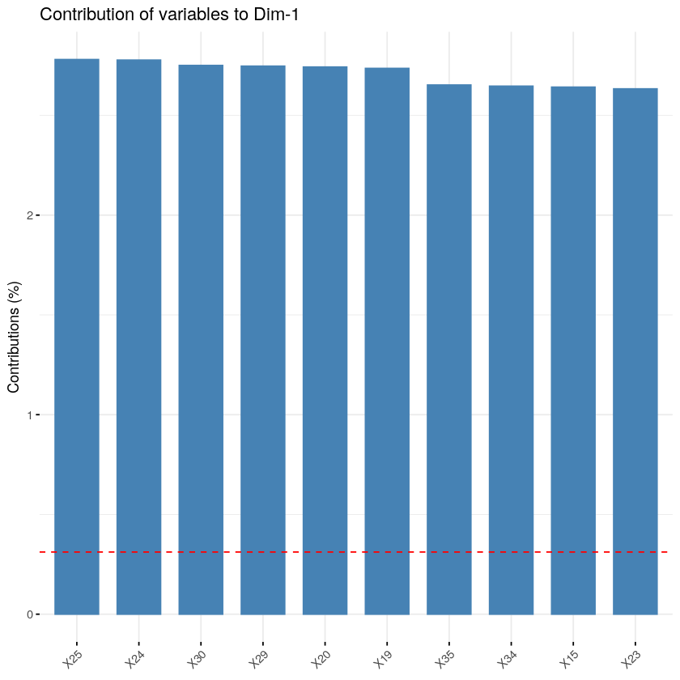

```r
# Las 10 variables que más contribuyen a la primera componente principal
fviz_contrib(meteo.pca, choice = "var", axes = 1, top = 10)
```

- Altura geopotencial en 500 hPa (columnas 2:41);
- Presión al nivel del mar (columnas 282:321).

### Saco las componentes principales, escalando las variables e incluiendo la variable objetivo

Parece evidente que una analisis de componente principales es sensible al rango de las variables del dataset.

Ya que el objetivo es entender cuales son las variables que explican la mayor parte de la varianza del dataset, independientemente del rango, vamos a repetir el ejercicio anterior, pero normalizando las variables.

```r
# Busco las componentes principales
meteo.pca.scale <- prcomp(meteo, scale = TRUE, center = TRUE)
```

```r
# Pinto la varianza explicada por cada componente
eigenvalues.scale <- get_eig(meteo.pca.scale)
eigenvalues.scale
```

A data.frame: 321 × 3

|  | eigenvalue <dbl> | variance.percent <dbl> | cumulative.variance.percent <dbl> |
| --- | --- | --- | --- |
| Dim.1 | 186,3477415 | 58,0522559 | 58,05226 |
| Dim.2 | 50,8560817 | 15,8430161 | 73,89527 |
| Dim.3 | 12,5584062 | 3,9122761 | 77,80755 |
| Dim.4 | 8,9703826 | 2,7945117 | 80,60206 |
| Dim.5 | 7,7530408 | 2,4152775 | 83,01734 |
| Dim.6 | 7,0236376 | 2,1880491 | 85,20539 |
| Dim.7 | 5,4831912 | 1,7081592 | 86,91355 |
| Dim.8 | 4,6532328 | 1,4496052 | 88,36315 |
| Dim.9 | 3,2313884 | 1,0066630 | 89,36981 |
| Dim.10 | 2,7745512 | 0,8643462 | 90,23416 |
| Dim.11 | 2,4049501 | 0,7492056 | 90,98337 |
| Dim.12 | 2,1483495 | 0,6692677 | 91,65263 |
| Dim.13 | 1,6496215 | 0,5139008 | 92,16653 |
| Dim.14 | 1,5827453 | 0,4930671 | 92,65960 |
| Dim.15 | 1,4301892 | 0,4455418 | 93,10514 |
| Dim.16 | 1,3648870 | 0,4251985 | 93,53034 |
| Dim.17 | 1,2911643 | 0,4022319 | 93,93257 |
| Dim.18 | 1,1013591 | 0,3431025 | 94,27568 |
| Dim.19 | 1,0168499 | 0,3167757 | 94,59245 |
| Dim.20 | 0,9704370 | 0,3023168 | 94,89477 |
| Dim.21 | 0,8623168 | 0,2686345 | 95,16340 |
| Dim.22 | 0,7821400 | 0,2436573 | 95,40706 |
| Dim.23 | 0,6998633 | 0,2180259 | 95,62509 |
| Dim.24 | 0,6626952 | 0,2064471 | 95,83153 |
| Dim.25 | 0,6426983 | 0,2002175 | 96,03175 |
| Dim.26 | 0,5730939 | 0,1785339 | 96,21028 |
| Dim.27 | 0,5398584 | 0,1681802 | 96,37847 |
| Dim.28 | 0,4905066 | 0,1528058 | 96,53127 |
| Dim.29 | 0,4752742 | 0,1480605 | 96,67933 |
| Dim.30 | 0,4463484 | 0,1390494 | 96,81838 |
| ⋮ | ⋮ | ⋮ | ⋮ |
| Dim.292 | 6,133738e-05 | 1,910822e-05 | 99,99982 |
| Dim.293 | 5,677249e-05 | 1,768614e-05 | 99,99983 |
| Dim.294 | 5,386548e-05 | 1,678052e-05 | 99,99985 |
| Dim.295 | 5,240237e-05 | 1,632473e-05 | 99,99987 |
| Dim.296 | 4,308425e-05 | 1,342188e-05 | 99,99988 |
| Dim.297 | 4,119609e-05 | 1,283367e-05 | 99,99989 |
| Dim.298 | 3,643802e-05 | 1,135141e-05 | 99,99990 |
| Dim.299 | 3,473753e-05 | 1,082166e-05 | 99,99992 |
| Dim.300 | 3,282604e-05 | 1,022618e-05 | 99,99993 |
| Dim.301 | 3,126464e-05 | 9,739763e-06 | 99,99994 |
| Dim.302 | 3,055471e-05 | 9,518601e-06 | 99,99994 |
| Dim.303 | 2,858930e-05 | 8,906323e-06 | 99,99995 |
| Dim.304 | 2,083659e-05 | 6,491148e-06 | 99,99996 |
| Dim.305 | 1,981227e-05 | 6,172045e-06 | 99,99997 |
| Dim.306 | 1,858020e-05 | 5,788224e-06 | 99,99997 |
| Dim.307 | 1,608921e-05 | 5,012215e-06 | 99,99998 |
| Dim.308 | 1,498523e-05 | 4,668296e-06 | 99,99998 |
| Dim.309 | 1,183384e-05 | 3,686555e-06 | 99,99999 |
| Dim.310 | 1,105349e-05 | 3,443454e-06 | 99,99999 |
| Dim.311 | 7,485221e-06 | 2,331845e-06 | 99,99999 |
| Dim.312 | 5,767566e-06 | 1,796750e-06 | 99,99999 |
| Dim.313 | 5,508767e-06 | 1,716127e-06 | 99,99999 |
| Dim.314 | 4,648980e-06 | 1,448280e-06 | 100,00000 |
| Dim.315 | 4,215450e-06 | 1,313224e-06 | 100,00000 |
| Dim.316 | 2,587881e-06 | 8,061936e-07 | 100,00000 |
| Dim.317 | 2,054803e-06 | 6,401256e-07 | 100,00000 |
| Dim.318 | 1,711433e-06 | 5,331568e-07 | 100,00000 |
| Dim.319 | 1,031944e-06 | 3,214780e-07 | 100,00000 |
| Dim.320 | 5,644741e-07 | 1,758486e-07 | 100,00000 |
| Dim.321 | 8,857016e-08 | 2,759195e-08 | 100,00000 |

```r
# Pinto la composición de cada componente principal
# en terminos de las variables
meteo.var.scale <- get_pca(meteo.pca.scale)
head(meteo.var.scale$contrib)
```

A matrix: 6 × 321 of type dbl

|  | Dim.1 | Dim.2 | Dim.3 | Dim.4 | Dim.5 | Dim.6 | Dim.7 | Dim.8 | Dim.9 | Dim.10 | ⋯ | Dim.312 | Dim.313 | Dim.314 | Dim.315 | Dim.316 | Dim.317 | Dim.318 | Dim.319 | Dim.320 | Dim.321 |
| --- | --- | --- | --- | --- | --- | --- | --- | --- | --- | --- | --- | --- | --- | --- | --- | --- | --- | --- | --- | --- | --- |
| y | 0,01068821 | 0,1481743 | 0,409296737 | 0,05626072 | 0,01623840 | 0,792168138 | 0,0250521714 | 0,69790165 | 0,697849413 | 0,03161560 | ⋯ | 2,237226e-07 | 1,286247e-09 | 2,938847e-07 | 1,209608e-07 | 1,485807e-08 | 1,979356e-07 | 1,713411e-08 | 1,221860e-08 | 6,538198e-08 | 2,518098e-09 |
| X1 | 0,32967378 | 0,3751500 | 0,003521151 | 1,08009249 | 0,18075169 | 0,314488693 | 0,0016369550 | 0,24096378 | 0,005042945 | 0,34950972 | ⋯ | 7,777296e-02 | 1,068744e-01 | 8,681547e-01 | 1,433569e-01 | 8,072046e-03 | 1,983905e-01 | 6,764049e-03 | 8,671875e-02 | 1,306187e-01 | 1,131101e-02 |
| X2 | 0,30982013 | 0,5400883 | 0,013331685 | 1,09103897 | 0,03021082 | 0,187355388 | 0,0003464903 | 0,03752520 | 0,013080701 | 0,30556854 | ⋯ | 2,909756e-01 | 4,237286e-01 | 3,499679e+00 | 7,077044e-02 | 4,551482e-03 | 1,146951e-01 | 8,981676e-02 | 5,972941e-01 | 5,249825e-01 | 1,033596e-01 |
| X3 | 0,28721888 | 0,6817707 | 0,037136982 | 0,90123571 | 0,02682396 | 0,071153722 | 0,0001308805 | 0,02896342 | 0,044093191 | 0,22138235 | ⋯ | 4,548429e-01 | 1,094653e+00 | 2,569606e+00 | 6,005903e-01 | 4,639561e-03 | 2,993693e-01 | 1,546034e-01 | 1,493890e+00 | 2,418529e-01 | 2,683617e-01 |
| X4 | 0,25893709 | 0,7623370 | 0,083838768 | 0,59147460 | 0,29705941 | 0,009772165 | 0,0013339786 | 0,29116858 | 0,123125140 | 0,13206158 | ⋯ | 7,382581e-01 | 3,701578e+00 | 8,421939e-02 | 2,062842e-02 | 9,782027e-03 | 2,876985e-01 | 5,761512e-02 | 1,572654e+00 | 2,355899e-02 | 2,721858e-01 |
| X5 | 0,22439603 | 0,7564979 | 0,158458134 | 0,29112473 | 0,84317813 | 0,002560493 | 0,0018319171 | 0,71326140 | 0,263361613 | 0,06108745 | ⋯ | 3,171919e-01 | 1,596047e+00 | 1,992596e-01 | 2,839820e-01 | 5,098566e-03 | 1,171771e-01 | 1,201050e-03 | 4,915030e-01 | 1,541826e-01 | 7,214683e-02 |

```r
# Contribución de la variable objetivo a la primera componente principal
print(paste("La contribución de la variable objetivo a la primera componente principal es:",
            format(round(meteo.var.scale$contrib[1,1],4), nsmall = 4)))
```

```
[1] "La contribución de la variable objetivo a la primera componente principal es: 0,0107"
```

```r
# Componente principal que recibe la contribución máxima de
# la variable objetivo

best.contrib.scale <- which(meteo.var.scale$contrib[1,] == max(meteo.var.scale$contrib[1,]))

print(paste("La contribución máxima de la variable objetivo es a la componente principal",
            best.contrib.scale,
            ". Hasta dicha componente principal se explica el",
            format(round(eigenvalues.scale$cumulative.variance.percent[best.contrib.scale],4), nsmall = 2),"%",
           "de la varianza"))
```

```
[1] "La contribución máxima de la variable objetivo es a la componente principal 23 . Hasta dicha componente principal se explica el 95,6251 % de la varianza"
```

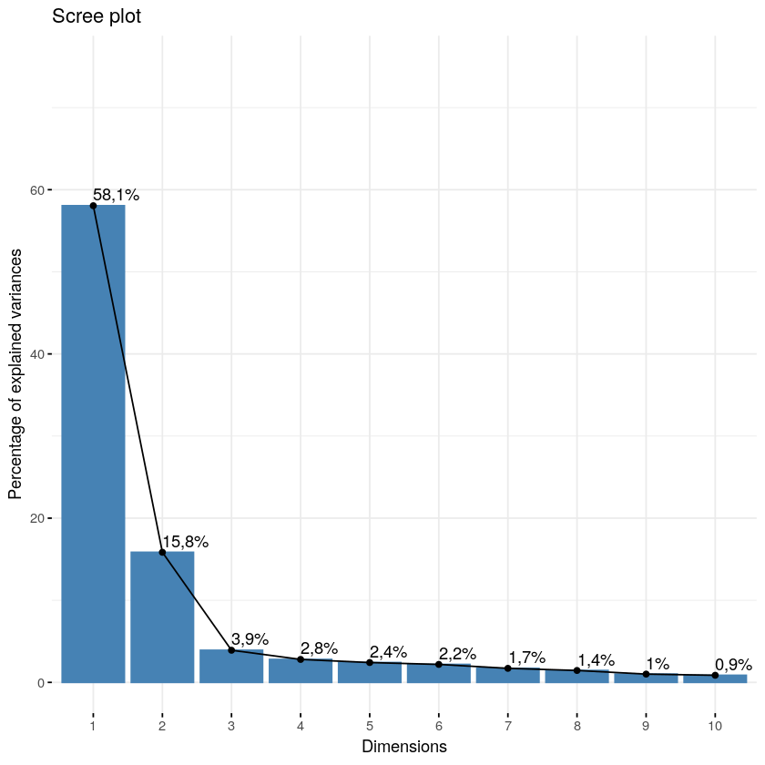

```r
# Plot del porcentage de varianza explicado por cada una de
# las primeras 10 componentes principales
fviz_screeplot(meteo.pca.scale, addlabels = TRUE, ylim = c(0, 75))
```

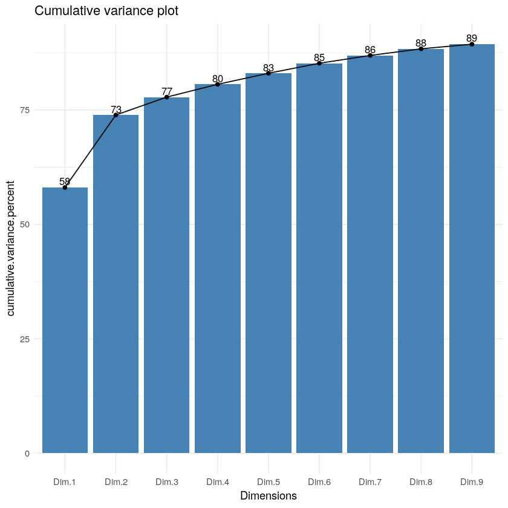

```r
# Plot del porcentage de varianza cumulada explicado por
# las primeras 9 componentes principales

plot.eigenvalues.scale <- eigenvalues.scale[1:9,]
plot.eigenvalues.scale$Dimensions <- row.names(plot.eigenvalues.scale)

ggplot(data=plot.eigenvalues.scale, aes(x=Dimensions, y = cumulative.variance.percent, group=1)) +
        geom_bar(stat="identity", fill="steelblue") +
        geom_text(aes(label=floor(cumulative.variance.percent)), vjust=-0.3, size=3.5) +
        geom_line(color="black") +
        geom_point() +
        ggtitle("Cumulative variance plot") +
        theme_minimal()
```

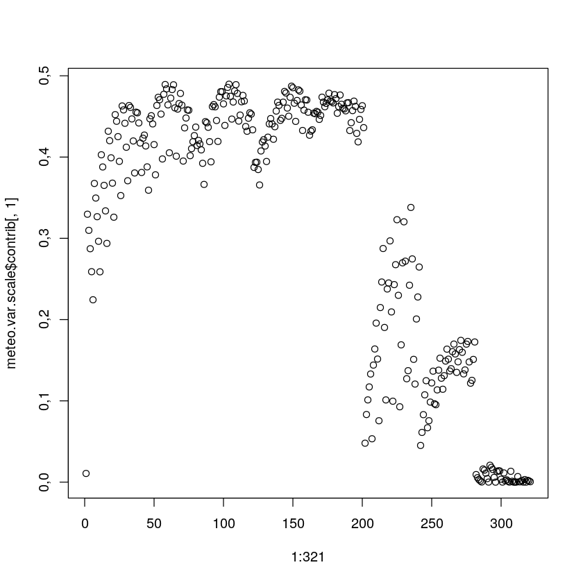

```r
# Contribución de cada variable a la primera componente principal
plot(1:321,meteo.var.scale$contrib[,1])
```

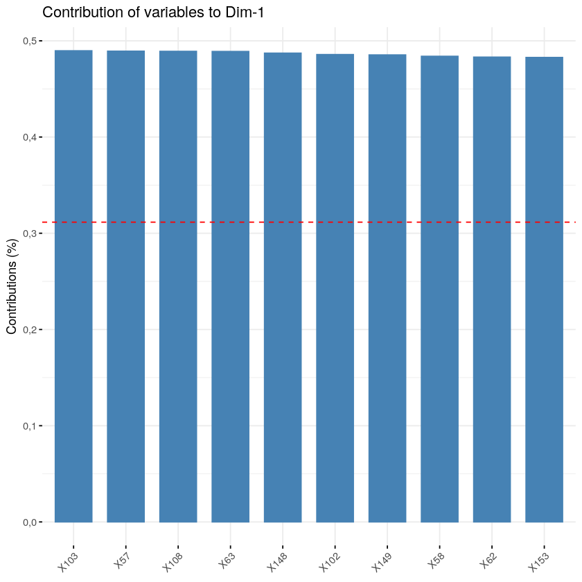

```r
# Las 10 variables que más contribuyen a la primera componente principal
fviz_contrib(meteo.pca.scale, choice = "var", axes = 1, top = 10)
```

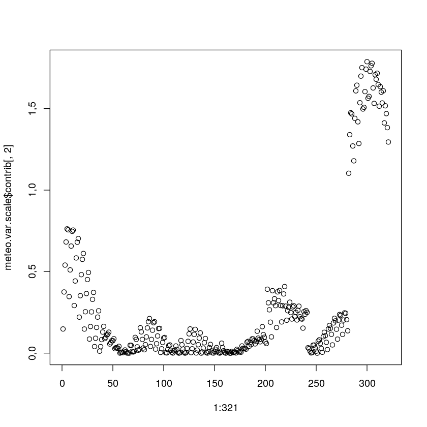

```r
# Contribución de cada variable a la segunda componente principal
plot(1:321,meteo.var.scale$contrib[,2])
```

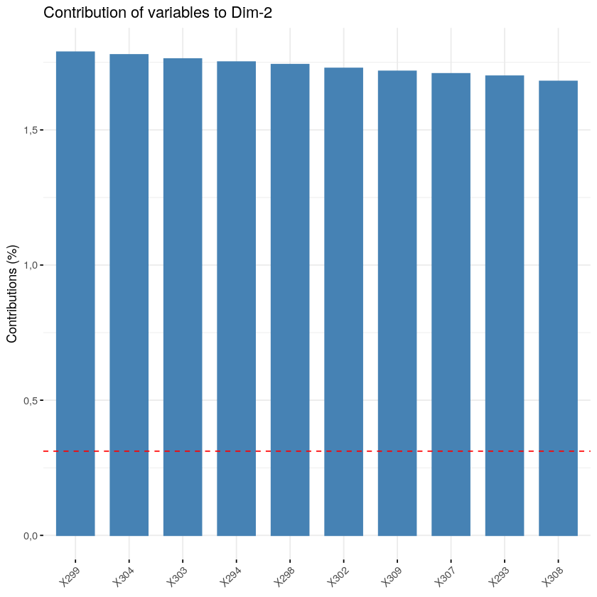

```r
# Las 10 variables que más contribuyen a la segunda componente principal
fviz_contrib(meteo.pca.scale, choice = "var", axes = 2, top = 10)
```

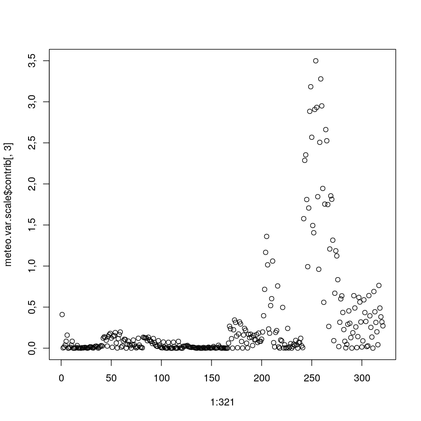

```r
# Contribución de cada variable a la tercera componente principal
plot(1:321,meteo.var.scale$contrib[,3])
```

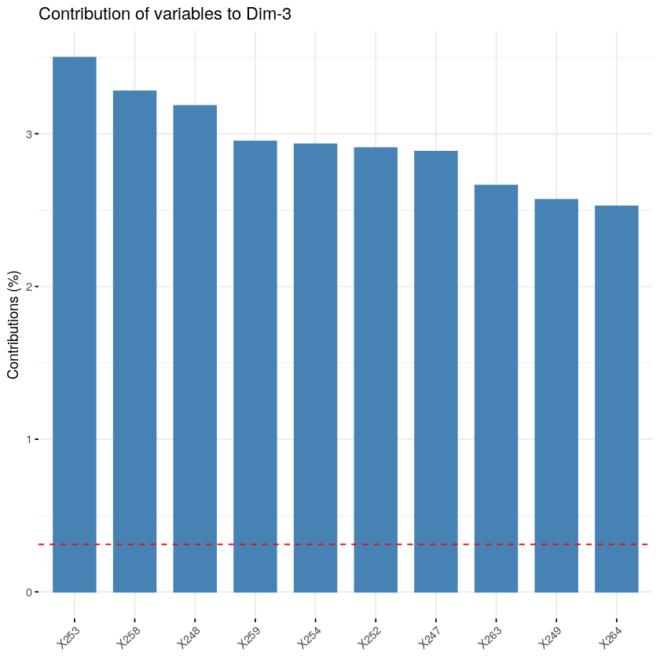

```r
# Las 10 variables que más contribuyen a la tercera componente principal
fviz_contrib(meteo.pca.scale, choice = "var", axes = 3, top = 10)
```

Escalando correctamente las variables, se observa que no hay dependencia del rango inicial en la composición de las componentes principales.

Podemos ver en la gráfica anterior, que en la primera componente principal hay una contribución importante por las primeras ~200 variables (excluyendo la variable objetivo), mientras que en la segunda componente principal adquieren importancia las que antes tenían un peso más bajo.

Esto demuestra que todas las variables contribuyen a la varianza del dataset, contrariamente a cuanto visto sin esclar.

Se nota también que ahora la variable objetivo sigue teniendo una contribución pequeña en general, aunque ya se note su efecto en la tercera componente.

### Punto 2 (3 puntos):

A continuación, consideraremos la serie de precipitación discretizada a partir del valor 1 mm, que es el estándar definido para establecer los días en que ha llovido. El objetivo de este apartado es predecir la ocurrencia de precipitación en Lisboa a partir de los predictores antes definidos. Para ello consideraremos, por un lado, las componentes principales obtenidas estandarizando los datos originales y, por otro lado, el método `KNN`. Dividir la muestra en dos subconjuntos, el primero (20 primeros años) lo utilizaremos para calibrar el modelo y obtener su configuración óptima, mientras que el segundo (10 últimos años) lo utilizaremos como test independiente de cara a comparar diferentes métodos.

- Considerad diferentes umbrales de varianza explicada y el número de PCs asociado (p.e. 40%, 60%, 80% y 90%) y obtend el valor óptimo de `K` en cada caso rastreando valores entre 1 y 15, ¿cómo cambia el valor óptimo? En base a los resultados obtenidos, ¿cuantas PCs considerarías para entrenar el modelo? (`Nota:` ver práctica de `KNN`)
- Para la configuración óptima calibrada con el conjunto de entrenamiento realizad la predicción sobre el conjunto de test y estimad los errores cometidos sobre este conjunto.

```r
# converto la variable objetivo en categórica
rain = ifelse(meteo$y < 1, 0, 1)
meteo$rain = as.factor(rain)
#print(paste(meteo$rain[1:10],meteo$y[1:10]))
```

```r
N <- nrow(meteo)
M <- ncol(meteo)

# creo el dataset de 'entrenamiento'
meteo.calib <- meteo[1:7300,2:M]

# creo el dataset de 'test'
meteo.test <- meteo[7301:N,2:M]
head(meteo.calib)
```

A data.frame: 6 × 321

|  | X1 <dbl> | X2 <dbl> | X3 <dbl> | X4 <dbl> | X5 <dbl> | X6 <dbl> | X7 <dbl> | X8 <dbl> | X9 <dbl> | X10 <dbl> | ⋯ | X312 <dbl> | X313 <dbl> | X314 <dbl> | X315 <dbl> | X316 <dbl> | X317 <dbl> | X318 <dbl> | X319 <dbl> | X320 <dbl> | rain <fct> |
| --- | --- | --- | --- | --- | --- | --- | --- | --- | --- | --- | --- | --- | --- | --- | --- | --- | --- | --- | --- | --- | --- |
| 1 | 57042,96 | 56534,84 | 55884,40 | 55175,59 | 54458,21 | 56980,27 | 56460,59 | 55800,02 | 55051,15 | 54318,77 | ⋯ | 101627,3 | 101357,2 | 101110,7 | 101291,0 | 101814,9 | 101479,4 | 101164,5 | 100970,7 | 100905,3 | 1 |
| 2 | 56963,20 | 56493,45 | 55930,82 | 55340,20 | 54768,63 | 56856,57 | 56361,95 | 55776,76 | 55164,26 | 54585,32 | ⋯ | 102069,7 | 102204,5 | 102480,3 | 102858,8 | 101973,3 | 102033,3 | 102165,5 | 102323,9 | 102534,2 | 0 |
| 3 | 56522,59 | 55971,40 | 55304,34 | 54498,03 | 53725,15 | 56514,84 | 55977,71 | 55327,28 | 54569,78 | 53863,46 | ⋯ | 102448,4 | 102438,3 | 102434,3 | 102339,8 | 102669,7 | 102565,5 | 102530,3 | 102453,6 | 102487,1 | 1 |
| 4 | 54627,98 | 53979,80 | 53494,05 | 53072,98 | 52616,36 | 54776,17 | 54089,05 | 53516,98 | 53012,86 | 52501,42 | ⋯ | 100672,8 | 100360,7 | 100133,7 | 100028,4 | 101126,2 | 100700,0 | 100381,3 | 100118,3 | 100319,8 | 0 |
| 5 | 53584,38 | 53391,01 | 53310,38 | 53292,82 | 53340,13 | 53781,70 | 53498,13 | 53306,82 | 53213,26 | 53157,38 | ⋯ | 100663,5 | 100747,7 | 100934,0 | 101015,8 | 100801,6 | 100685,3 | 100777,5 | 100909,4 | 101164,7 | 0 |
| 6 | 54221,86 | 54220,24 | 54328,55 | 54772,49 | 55251,11 | 54391,11 | 54345,93 | 54284,05 | 54525,99 | 55012,61 | ⋯ | 101511,5 | 101798,9 | 102142,2 | 102368,5 | 101438,7 | 101440,9 | 101685,3 | 102030,7 | 102311,9 | 1 |

```r
# Vuelvo a sacar las componentes principales para
# el dataset de 'entrenamiento'

# (No considero la variable objetivo)
meteo.pca.calib <- prcomp(meteo.calib[,1:320], scale = TRUE, center = TRUE)
meteo.pca.calib$x
```

A matrix: 7300 × 320 of type dbl

[output not shown]

```r
# Pinto la varianza explicada por cada componente
eigenvalues.calib <- get_eig(meteo.pca.calib)
eigenvalues.calib
```

A data.frame: 320 × 3

|  | eigenvalue <dbl> | variance.percent <dbl> | cumulative.variance.percent <dbl> |
| --- | --- | --- | --- |
| Dim.1 | 186,1227976 | 58,1633742 | 58,16337 |
| Dim.2 | 51,2686298 | 16,0214468 | 74,18482 |
| Dim.3 | 12,4084848 | 3,8776515 | 78,06247 |
| Dim.4 | 9,1443674 | 2,8576148 | 80,92009 |
| Dim.5 | 7,5594526 | 2,3623289 | 83,28242 |
| Dim.6 | 7,0488463 | 2,2027645 | 85,48518 |
| Dim.7 | 5,4332128 | 1,6978790 | 87,18306 |
| Dim.8 | 4,6211429 | 1,4441072 | 88,62717 |
| Dim.9 | 3,2809893 | 1,0253091 | 89,65248 |
| Dim.10 | 2,7134682 | 0,8479588 | 90,50043 |
| Dim.11 | 2,3234061 | 0,7260644 | 91,22650 |
| Dim.12 | 2,1457303 | 0,6705407 | 91,89704 |
| Dim.13 | 1,6232641 | 0,5072700 | 92,40431 |
| Dim.14 | 1,5759823 | 0,4924945 | 92,89680 |
| Dim.15 | 1,3914919 | 0,4348412 | 93,33165 |
| Dim.16 | 1,3623622 | 0,4257382 | 93,75738 |
| Dim.17 | 1,2816391 | 0,4005122 | 94,15790 |
| Dim.18 | 1,1105953 | 0,3470610 | 94,50496 |
| Dim.19 | 1,0154562 | 0,3173301 | 94,82229 |
| Dim.20 | 0,9771817 | 0,3053693 | 95,12766 |
| Dim.21 | 0,8521010 | 0,2662816 | 95,39394 |
| Dim.22 | 0,7509193 | 0,2346623 | 95,62860 |
| Dim.23 | 0,6865204 | 0,2145376 | 95,84314 |
| Dim.24 | 0,6531979 | 0,2041244 | 96,04726 |
| Dim.25 | 0,5861225 | 0,1831633 | 96,23043 |
| Dim.26 | 0,5296758 | 0,1655237 | 96,39595 |
| Dim.27 | 0,4969728 | 0,1553040 | 96,55125 |
| Dim.28 | 0,4802506 | 0,1500783 | 96,70133 |
| Dim.29 | 0,4613547 | 0,1441734 | 96,84550 |
| Dim.30 | 0,4330028 | 0,1353134 | 96,98082 |
| ⋮ | ⋮ | ⋮ | ⋮ |
| Dim.291 | 5,740646e-05 | 1,793952e-05 | 99,99983 |
| Dim.292 | 5,298965e-05 | 1,655926e-05 | 99,99985 |
| Dim.293 | 4,948730e-05 | 1,546478e-05 | 99,99986 |
| Dim.294 | 4,728523e-05 | 1,477663e-05 | 99,99988 |
| Dim.295 | 3,910172e-05 | 1,221929e-05 | 99,99989 |
| Dim.296 | 3,729465e-05 | 1,165458e-05 | 99,99990 |
| Dim.297 | 3,316441e-05 | 1,036388e-05 | 99,99991 |
| Dim.298 | 3,168296e-05 | 9,900923e-06 | 99,99992 |
| Dim.299 | 3,042290e-05 | 9,507156e-06 | 99,99993 |
| Dim.300 | 2,831736e-05 | 8,849174e-06 | 99,99994 |
| Dim.301 | 2,741041e-05 | 8,565753e-06 | 99,99995 |
| Dim.302 | 2,549312e-05 | 7,966599e-06 | 99,99996 |
| Dim.303 | 2,002624e-05 | 6,258200e-06 | 99,99996 |
| Dim.304 | 1,825380e-05 | 5,704311e-06 | 99,99997 |
| Dim.305 | 1,674556e-05 | 5,232987e-06 | 99,99997 |
| Dim.306 | 1,495843e-05 | 4,674511e-06 | 99,99998 |
| Dim.307 | 1,331251e-05 | 4,160161e-06 | 99,99998 |
| Dim.308 | 1,122968e-05 | 3,509275e-06 | 99,99999 |
| Dim.309 | 1,012240e-05 | 3,163251e-06 | 99,99999 |
| Dim.310 | 6,732190e-06 | 2,103809e-06 | 99,99999 |
| Dim.311 | 5,500450e-06 | 1,718891e-06 | 99,99999 |
| Dim.312 | 5,102185e-06 | 1,594433e-06 | 100,00000 |
| Dim.313 | 4,243455e-06 | 1,326080e-06 | 100,00000 |
| Dim.314 | 3,837142e-06 | 1,199107e-06 | 100,00000 |
| Dim.315 | 2,437675e-06 | 7,617733e-07 | 100,00000 |
| Dim.316 | 1,866831e-06 | 5,833846e-07 | 100,00000 |
| Dim.317 | 1,648131e-06 | 5,150409e-07 | 100,00000 |
| Dim.318 | 9,360895e-07 | 2,925280e-07 | 100,00000 |
| Dim.319 | 5,194206e-07 | 1,623190e-07 | 100,00000 |
| Dim.320 | 8,224409e-08 | 2,570128e-08 | 100,00000 |

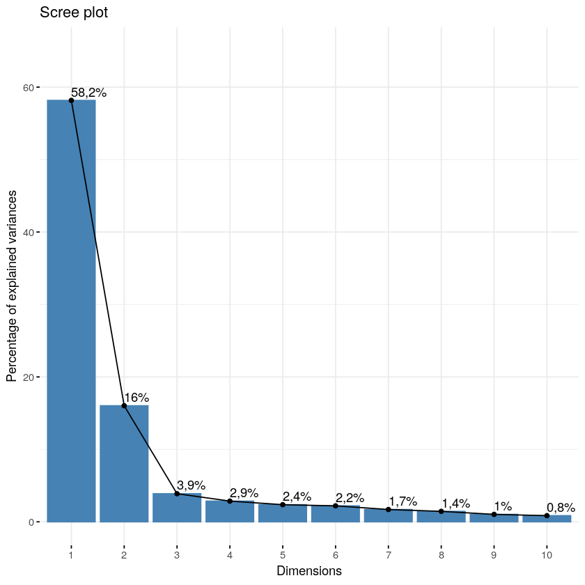

```r
# Plot del porcentage de varianza explicado por cada una de
# las primeras 10 componentes principales
fviz_screeplot(meteo.pca.calib, addlabels = TRUE, ylim = c(0, 65))
```

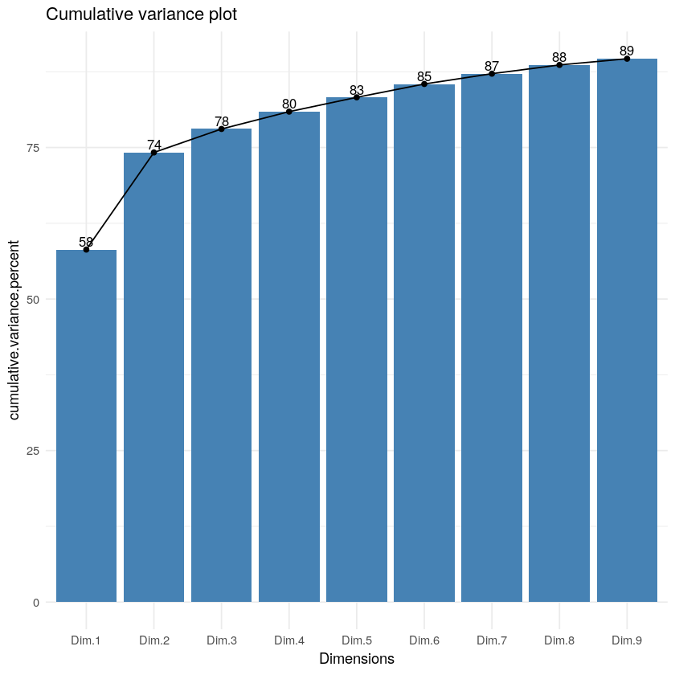

```r
# Plot del porcentage de varianza cumulada explicado por
# las primeras 9 componentes principales

plot.eigenvalues.calib <- eigenvalues.calib[1:9,]
plot.eigenvalues.calib$Dimensions <- row.names(plot.eigenvalues.calib)

ggplot(data=plot.eigenvalues.calib, aes(x=Dimensions, y = cumulative.variance.percent, group=1)) +
        geom_bar(stat="identity", fill="steelblue") +
        geom_text(aes(label=floor(cumulative.variance.percent)), vjust=-0.3, size=3.5) +
        geom_line(color="black") +
        geom_point() +
        ggtitle("Cumulative variance plot") +
        theme_minimal()
```

```r
library(caret)

thresholds <- c(0.6, 0.8, 0.9)

knn.vector = c()

for (i in thresholds){

    print(paste("Entrenamiento usando",i*100,"% de la varianza"))

    # cambio el umbral de varianza
    ctrl <- trainControl(method = "cv",
                     number = 3,
                     preProcOptions = list(thresh = i))

    # cambio el número de vecinos cercanos
    knn <- train(rain ~ ., meteo.calib,
                     method = "knn",
                     preProcess = c("center", "scale", "pca"),
                     trControl = ctrl,
                     tuneGrid = expand.grid(k = 1:15))

    knn.vector = c(knn.vector, knn)
    # imprimo los resultados
    #print(knn)

    # pinto los resultados (no funciona)
    plot(knn)
}
```

```
[1] "Entrenamiento usando 60 % de la varianza"
[1] "Entrenamiento usando 80 % de la varianza"
[1] "Entrenamiento usando 90 % de la varianza"
```

```r
# Ahora hago la rotación del dataset de test para el espacio de los PCA

# Hago el scale del dataset de test
s.meteo.test <- scale(meteo.test[,1:320], center= meteo.pca.calib$center)

# Ahora puedo hacer la rotación
meteo.pca.test <- s.meteo.test %*% meteo.pca.calib$rotation
head(meteo.pca.test)
```

A matrix: 6 × 320 of type dbl

|  | PC1 | PC2 | PC3 | PC4 | PC5 | PC6 | PC7 | PC8 | PC9 | PC10 | ⋯ | PC311 | PC312 | PC313 | PC314 | PC315 | PC316 | PC317 | PC318 | PC319 | PC320 |
| --- | --- | --- | --- | --- | --- | --- | --- | --- | --- | --- | --- | --- | --- | --- | --- | --- | --- | --- | --- | --- | --- |
| 7301 | 7,625795 | 7,225602 | -2,0309674 | 2,7898641 | 6,3025183 | 2,50027891 | -2,6461400 | 1,5988212 | -4,1059566 | -0,02489308 | ⋯ | 0,0022764562 | 3,842583e-03 | 0,0008667704 | -0,005548367 | -0,0004559263 | 0,0005159244 | -0,0020397996 | 0,0026229174 | -0,0003864795 | -3,801858e-04 |
| 7302 | 14,825078 | -0,334579 | -0,1294430 | 3,0489783 | 1,7496991 | 0,40991965 | -0,3528569 | -0,4936798 | -2,8984553 | 0,45671999 | ⋯ | -0,0016363412 | 1,427615e-03 | -0,0008220928 | -0,001201217 | -0,0011442256 | 0,0011965892 | -0,0035890598 | 0,0006618821 | 0,0001393184 | 7,035480e-05 |
| 7303 | 12,483250 | -6,428301 | -2,7371409 | 0,6874954 | -0,6916853 | 6,00701255 | -2,7138330 | -1,3816693 | -2,4525846 | 1,24422489 | ⋯ | 0,0045369125 | 3,507134e-03 | -0,0001483628 | 0,001622337 | 0,0010970183 | 0,0004314203 | 0,0003871709 | 0,0006669700 | 0,0011030610 | -5,065220e-05 |
| 7304 | 17,195077 | -10,123003 | -0,5637715 | 5,5026917 | 1,4067341 | 0,05041138 | -0,6597657 | 1,9653361 | -0,3862812 | 1,01671625 | ⋯ | 0,0006545594 | -1,142777e-03 | -0,0018758102 | -0,002341835 | -0,0025238840 | -0,0001616545 | -0,0007749711 | 0,0007584128 | 0,0008654112 | 2,473009e-04 |
| 7305 | 21,705761 | -12,976006 | 0,6820448 | 2,9325695 | 1,4981152 | 2,42704690 | -1,0514934 | 0,3889349 | 0,1313114 | 0,19602784 | ⋯ | -0,0021288816 | -8,270176e-05 | -0,0012821546 | 0,002104203 | -0,0014280417 | -0,0020221384 | 0,0007841765 | -0,0005498913 | -0,0003432636 | 2,598923e-05 |
| 7306 | 22,187438 | -10,371840 | 1,7458537 | -0,8424255 | 0,2704161 | 1,67100839 | -1,9616241 | 3,4613319 | 1,8831429 | -0,71316807 | ⋯ | -0,0041047385 | 3,886690e-03 | -0,0012265908 | -0,001933464 | 0,0002092119 | -0,0022103254 | 0,0017310038 | 0,0018492611 | -0,0007920937 | -4,695988e-04 |

```r
# Usando el 90% de la varianza (10 componentes principales),
# y 7 vecinos cercanos, espero obtener el 85% de tasa de acierto

n.pca = 10
ka = 7

library(class)

pred <- knn(train = meteo.pca.calib$x[,1:n.pca],
            test = meteo.pca.test[,1:n.pca],
            cl = meteo.calib$rain,
            k = ka)
```

```r
# Función para evaluar la tasa de acierto
acc.class = function(x, y) {
  stopifnot(length(x) == length(y))
  return(sum(diag(table(x, y))) / length(x))
}
```

```r
# El resultado que obtengo aplicando el método al dataset de test
print(paste("Usando", n.pca,"componentes principales y",ka,"vecinos cercanos obtengo una tasa de acierto de:",
            format(round(acc.class(pred, meteo.test$rain)*100,2), nsmall = 2),"%"))
```

```
[1] "Usando 10 componentes principales y 7 vecinos cercanos obtengo una tasa de acierto de: 85,10 %"
```

```r
# Miro más en detalle los resultados para el dataset de test
print(paste("Días con lluvia (1) y sin lluvia (0) en el dataset de test:"))
table(meteo.test$rain)

print(paste("Martiz de confusión el dataset de test:"))
table(pred, meteo.test$rain)
```

```
[1] "Días con lluvia (1) y sin lluvia (0) en el dataset de test:"
```

```
   0    1
2943  715
```

```
[1] "Martiz de confusión el dataset de test:"
```

```
pred    0    1
   0 2783  385
   1  160  330
```

### Punto 3 (2 puntos):

Repetid el experimento anterior considerando la precipitación discretizada a partir del valor 20 mm, que es el estándar definido para establecer los días en que ha llovido de forma intensa.

- ¿Cómo cambian los valores óptimos de `K` y de número de PCs?
- ¿Cómo cambian los errores sobre el conjunto de test en este caso?
- En caso de existir diferentes significativas en ambos casos, ¿a qué crees que puede ser debido? ¿La frecuencia en la muestra del evento a predecir puede influir en la calidad de la predicción?

```r
# converto la variable objetivo en categórica
heavy.rain = ifelse(meteo$y < 20, 0, 1)
meteo$heavy.rain = as.factor(heavy.rain)
```

```r
N <- nrow(meteo)
M <- ncol(meteo)

# creo el dataset de 'entrenamiento'
meteo.calib <- meteo[1:7300,2:M]

# creo el dataset de 'test'
meteo.test <- meteo[7301:N,2:M]
head(meteo.calib)
```

A data.frame: 6 × 322

|  | X1 <dbl> | X2 <dbl> | X3 <dbl> | X4 <dbl> | X5 <dbl> | X6 <dbl> | X7 <dbl> | X8 <dbl> | X9 <dbl> | X10 <dbl> | ⋯ | X313 <dbl> | X314 <dbl> | X315 <dbl> | X316 <dbl> | X317 <dbl> | X318 <dbl> | X319 <dbl> | X320 <dbl> | rain <fct> | heavy.rain <fct> |
| --- | --- | --- | --- | --- | --- | --- | --- | --- | --- | --- | --- | --- | --- | --- | --- | --- | --- | --- | --- | --- | --- |
| 1 | 57042,96 | 56534,84 | 55884,40 | 55175,59 | 54458,21 | 56980,27 | 56460,59 | 55800,02 | 55051,15 | 54318,77 | ⋯ | 101357,2 | 101110,7 | 101291,0 | 101814,9 | 101479,4 | 101164,5 | 100970,7 | 100905,3 | 1 | 0 |
| 2 | 56963,20 | 56493,45 | 55930,82 | 55340,20 | 54768,63 | 56856,57 | 56361,95 | 55776,76 | 55164,26 | 54585,32 | ⋯ | 102204,5 | 102480,3 | 102858,8 | 101973,3 | 102033,3 | 102165,5 | 102323,9 | 102534,2 | 0 | 0 |
| 3 | 56522,59 | 55971,40 | 55304,34 | 54498,03 | 53725,15 | 56514,84 | 55977,71 | 55327,28 | 54569,78 | 53863,46 | ⋯ | 102438,3 | 102434,3 | 102339,8 | 102669,7 | 102565,5 | 102530,3 | 102453,6 | 102487,1 | 1 | 0 |
| 4 | 54627,98 | 53979,80 | 53494,05 | 53072,98 | 52616,36 | 54776,17 | 54089,05 | 53516,98 | 53012,86 | 52501,42 | ⋯ | 100360,7 | 100133,7 | 100028,4 | 101126,2 | 100700,0 | 100381,3 | 100118,3 | 100319,8 | 0 | 0 |
| 5 | 53584,38 | 53391,01 | 53310,38 | 53292,82 | 53340,13 | 53781,70 | 53498,13 | 53306,82 | 53213,26 | 53157,38 | ⋯ | 100747,7 | 100934,0 | 101015,8 | 100801,6 | 100685,3 | 100777,5 | 100909,4 | 101164,7 | 0 | 0 |
| 6 | 54221,86 | 54220,24 | 54328,55 | 54772,49 | 55251,11 | 54391,11 | 54345,93 | 54284,05 | 54525,99 | 55012,61 | ⋯ | 101798,9 | 102142,2 | 102368,5 | 101438,7 | 101440,9 | 101685,3 | 102030,7 | 102311,9 | 1 | 0 |

```
[1] "Entrenamiento usando 60 % de la varianza"
k-Nearest Neighbors

7300 samples
 320 predictor
   2 classes: '0', '1'

Pre-processing: centered (320), scaled (320), principal component
 signal extraction (320)
Resampling: Cross-Validated (3 fold)
Summary of sample sizes: 4866, 4867, 4867
Resampling results across tuning parameters:

  k   Accuracy   Kappa
   1  0,9491776   0,0203808939
   2  0,9490413   0,0533878492
   3  0,9697258   0,0008753621
   4  0,9706848   0,0022192061
   5  0,9735616   0,0078027255
   6  0,9735616   0,0078106993
   7  0,9742466  -0,0002698791
   8  0,9741096  -0,0005317415
   9  0,9743836   0,0000000000
  10  0,9743836   0,0000000000
  11  0,9743836   0,0000000000
  12  0,9743836   0,0000000000
  13  0,9743836   0,0000000000
  14  0,9743836   0,0000000000
  15  0,9743836   0,0000000000

Accuracy was used to select the optimal model using the largest value.
The final value used for the model was k = 15.
[1] "Entrenamiento usando 80 % de la varianza"
k-Nearest Neighbors

7300 samples
 320 predictor
   2 classes: '0', '1'

Pre-processing: centered (320), scaled (320), principal component
```

[output cut: 41 more lines]

```
   4  0,9708217   0,0767382726
   5  0,9730136   0,0440618690
   6  0,9728766   0,0166658038
   7  0,9736987  -0,0013177262
   8  0,9742465   0,0193800375
   9  0,9739726  -0,0008016206
  10  0,9743837   0,0100508629
  11  0,9743836   0,0099015421
  12  0,9742466  -0,0002698791
  13  0,9743836   0,0000000000
  14  0,9743836   0,0000000000
  15  0,9743836   0,0000000000

Accuracy was used to select the optimal model using the largest value.
The final value used for the model was k = 10.
```

[figure not shown]

```r
# Repito la calibración

thresholds <- c(0.6, 0.8, 0.9)

knn.vector <- c()

zeros <- rep(0,15)
plot(1:15, zeros, type = "l",
     xlab = "Neighbours",
     ylab = "Accuracy (repeated cross validation)",
     main = paste("Accuracy vs number of neighbours"),
     ylim = c(0,1))

# Just counter for the colours
cols <- rainbow(4)
p <- 1

for (i in thresholds){

    print(paste("Entrenamiento usando",i*100,"% de la varianza"))

    # cambio el umbral de varianza
    ctrl <- trainControl(method = "cv",
                     number = 3,
                     preProcOptions = list(thresh = i))

    # cambio el número de vecinos cercanos
    knn <- train(heavy.rain ~ ., meteo.calib[,-321],
                     method = "knn",
                     preProcess = c("center", "scale", "pca"),
                     trControl = ctrl,
                     tuneGrid = expand.grid(k = 1:15))

    knn.vector <- c(knn.vector, knn)

    # imprimo los resultados
    print(knn)

    # pinto los resultados (no funciona)
    plot(knn,
         col = cols[p],
         add = T)

    p <- p + 1
}

legend("bottomright", legend=paste("Variance:",thresholds), lwd=2, col=cols)
```

```r
# Usando el 80% de la varianza (4 componente principal),
# y 7 vecinos cercanos, espero obtener el 97% de tasa de acierto

n.pca = 4
ka = 7

library(class)

# Predicción de train
pred.train <- knn(train = meteo.pca.calib$x[,1:n.pca],
                test = meteo.pca.calib$x[,1:n.pca],
                cl = meteo.calib$heavy.rain,
                k = ka)

# Predicción de test
pred <- knn(train = meteo.pca.calib$x[,1:n.pca],
            test = meteo.pca.test[,1:n.pca],
            cl = meteo.calib$heavy.rain,
            k = ka)
```

```r
# El resultado que obtengo aplicando el método al dataset de test
print(paste("Usando", n.pca,"componentes principales y",ka,"vecinos cercanos obtengo una tasa de acierto de:",
            format(round(acc.class(pred, meteo.test$heavy.rain)*100,2), nsmall = 2),"%"))
```

```
[1] "Usando 4 componentes principales y 7 vecinos cercanos obtengo una tasa de acierto de: 97,43 %"
```

```r
# Miro más en detalle los resultados para el dataset de train
print(paste("Días con lluvia (1) y sin lluvia (0) en el dataset de calibración:"))
table(meteo.calib$rain)

print(paste("Días con lluvia fuerte (1) y sin lluvia fuerte (0) en el dataset de calibración:"))
table(meteo.calib$heavy.rain)

print(paste("Martiz de confusión el dataset de calibración:"))
table(pred.train, meteo.calib$heavy.rain)
```

```
[1] "Días con lluvia (1) y sin lluvia (0) en el dataset de calibración:"
```

```
   0    1
5790 1510
```

```
[1] "Días con lluvia fuerte (1) y sin lluvia fuerte (0) en el dataset de calibración:"
```

```
   0    1
7113  187
```

```
[1] "Martiz de confusión el dataset de calibración:"
```

```
pred.train    0    1
         0 7109  181
         1    4    6
```

```r
# Miro más en detalle los resultados para el dataset de test
print(paste("Días con lluvia (1) y sin lluvia (0) en el dataset de test:"))
table(meteo.test$rain)

print(paste("Días con lluvia fuerte (1) y sin lluvia fuerte (0) en el dataset de test:"))
table(meteo.test$heavy.rain)

print(paste("Martiz de confusión el dataset de test:"))
table(pred, meteo.test$heavy.rain)
```

```
[1] "Días con lluvia (1) y sin lluvia (0) en el dataset de test:"
```

```
   0    1
2943  715
```

```
[1] "Días con lluvia fuerte (1) y sin lluvia fuerte (0) en el dataset de test:"
```

```
   0    1
3565   93
```

```
[1] "Martiz de confusión el dataset de test:"
```

```
pred    0    1
   0 3562   91
   1    3    2
```

No obstante tanto en el caso del dataset de calibración como en el caso del dataset de test la tasa de acierto sea muy alta (97%), si miramos más en detalle la matriz de confusión, vemos que los resultados son engañosos: básicamente los resultados son muy próximos al 100% de efectividad porque casi siempre el resultado es que no hay lluvia fuerte (lo cuál es verdad).

Lo que el método no sabe reconocer es cuando efectivamente hay mucha lluvia, como se nota mirando la composición de los datasets y la matriz de confusión: tanto en el dataset de calibración como en el dataset de test, la entrada ["1","1"] de la matriz tiene muy valores muy bajos, mucho menos de los pocos que esperamos.

Dicho de otra forma, hay muchisimos casos de falsos negativos: hay lluvia fuerte, pero el método predice que no va a llover.

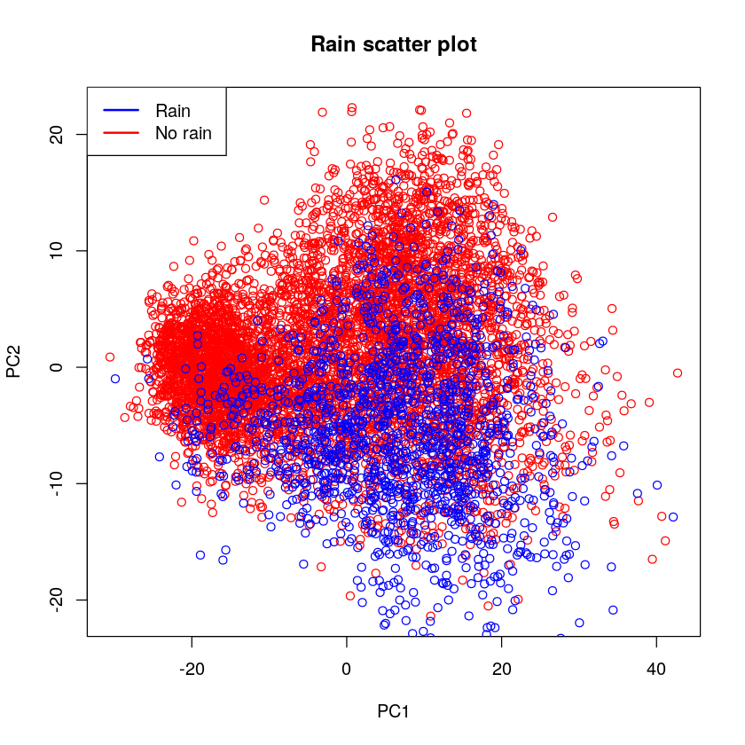

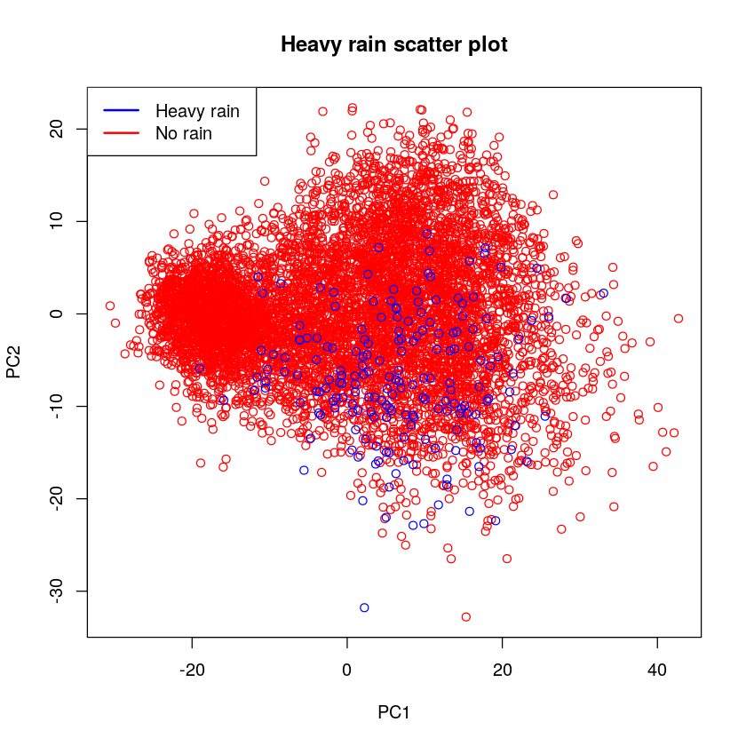

```r
# Busco entender por qué el método knn parece no funcionar
# para los días de lluvia fuerte
df.plot <- meteo.pca.calib$x[,1:2]
df.plot <- data.frame(df.plot, meteo.calib$heavy.rain, meteo.calib$rain)
names(df.plot) = c("PC1","PC2","heavy.rain","rain")

# Pinto un scatter plot de las 2 componentes principales
# para días de lluvia y días sin lluvia
df.plot.rain <- df.plot[df.plot$rain == 1,]
df.plot.no.rain <- df.plot[df.plot$rain == 0,]

plot(df.plot.no.rain$PC1, df.plot.no.rain$PC2,
    col = "red",
    main = "Rain scatter plot",
    xlab = "PC1",
    ylab = "PC2")
points(df.plot.rain$PC1,df.plot.rain$PC2,
    col = "blue")
legend("topleft", legend=c("Rain","No rain"), lwd=2, col=c("blue","red"))


# Pinto un scatter plot de las 2 componentes principales
# para días de lluvia fuerte y días sin lluvia
df.plot.heavy.rain <- df.plot[df.plot$heavy.rain == 1,]
df.plot.no.heavy.rain <- df.plot[df.plot$heavy.rain == 0,]

plot(df.plot.no.heavy.rain$PC1,df.plot.no.heavy.rain$PC2,
    col = "red",
    main = "Heavy rain scatter plot",
    xlab = "PC1",
    ylab = "PC2")
points(df.plot.heavy.rain$PC1,df.plot.heavy.rain$PC2,
    col = "blue")
legend("topleft", legend=c("Heavy rain","No rain"), lwd=2, col=c("blue","red"))
```

Mientras en el caso de clasificar días de lluvia y días sin lluvia (apartado anterior) el método producia resultados razonables al mirar la matriz de confusión (había falsos positivos y falsos negativos, pero aproximadamente del mismo orden de magnitud), para días de fuerte lluvia se nota que el método sólo es capaz de decir que no va a haber mucha lluvia.

no se puede decir lo mismo en el caso de lluvia fuerte:

- 187 días con lluvia fuerte;
- 7113 días sin lluvia fuerte.

Lo que típicamente pasa en estos casos, si el método utilizado para la clasificación no está entrenado especificamente teniendo en cuenta esta caracteristica del dataset, es que el clasificador intenta predecir en la mayoría de los casos la clase más frecuente, pero sin haber verdaderamente *entendido* el dataset.

En el caso de knn, no hay un verdadero aprendizaje por parte del modelo, que simplemente computa distancias entre puntos en el espacio n-dimensional del dataset. Para tener una idea de lo que pasa en el ejemplo de este ejercicio, he pintado un scatter plot de las dos componentes principales en los siguientes casos:

- días de lluvia frente a días sin lluvia;
- días de lluvia fuerte frente a días sin lluvia fuerte.

La diferencia es muy clara: mientras que para los días de lluvia, aunque los dos subconjuntos de puntos (rojos y azules) solapen de manera significativa (estamos usando solo dos componentes principales, demasiado pocas para obtener una buena separación) se nota que están agrupados, formando cada uno un bloque separado, y que los dos tienen un número significativo de elementos.

Esto significa que, al poner un nuevo elemento, podemos esperar que los vecinos más cercanos sean efectivamente los del mismo grupo, al menos en la mayoria de los casos, permitiendo sacar una clasificación realista.

La situación en el caso de fuerte lluvia es muy distinta, ya que el número de elementos es tán pequeño que se hace muy complicado, hasta para un día verdaderamente de fuerte lluvia, ser *rodeado* por elementos etiquetados como días de fuerte lluvia y ser clasificado como tal.

### Punto 4 (2 puntos):

Considerando el número de PCs óptimo obtenido en el apartado anterior, predecid el conjunto de test utilizando en este caso la regresión logística como método de clasificación (`Nota:` ver `Práctica Clasificacion Lineal` en el Moodle de la asignatura de Estadística o en la de Minería de Datos).

- Comparad los resultados obtenidos utilizando ambos métodos para la predicción de la ocurrencia de precipitación y de precipitación intensa (`Nota:` considerar, por ejemplo, la curva ROC para la comparación), ¿alguno de los métodos se comporta mejor que el otro de forma sistemática?

#### Lluvia

```r
n.pca = 10

# defino el data.frame de entrenamiento
df.glm.train.rain <- meteo.pca.calib$x[,1:n.pca]
df.glm.train.rain <- data.frame(df.glm.train.rain, meteo.calib$rain)
names(df.glm.train.rain) = c("PC1","PC2","PC3","PC4","PC5","PC6","PC7","PC8","PC9","PC10","rain")

# entreno el modelo
logistic.regr.rain <- glm(df.glm.train.rain$rain~., data = df.glm.train.rain, family = binomial(link = "logit"))
```

```
[1] "Accuracy sobre el datset de train:"
```

87,5068493150685

```
[1] "Días con lluvia (1) y sin lluvia (0) en el dataset de entrenamiento:"
```

```
   0    1
5790 1510
```

```
[1] "Matriz de confusión de entrenamiento:"
```

```
   out.bin.train.rain
       0    1
  0 5481  309
  1  603  907
```

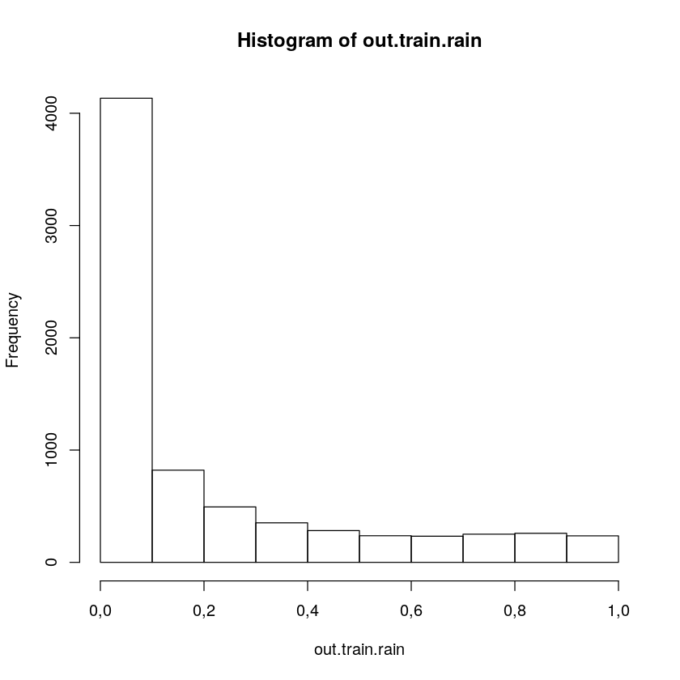

```r
# Tasa de acierto (Train)
out.train.rain <- logistic.regr.rain$fitted.values
out.bin.train.rain <- as.double(out.train.rain > 0.5)
print("Accuracy sobre el datset de train:")
100*sum(diag(table(df.glm.train.rain[,n.pca+1], out.bin.train.rain))) / length(out.bin.train.rain)

# Histograma de salida del modelo
hist(out.train.rain)

print(paste("Días con lluvia (1) y sin lluvia (0) en el dataset de entrenamiento:"))
table(meteo.calib$rain)

# Matriz de confusión de entrenamiento
print("Matriz de confusión de entrenamiento:")
table(meteo.calib$rain, out.bin.train.rain)
```

```r
# defino el data.frame de test
df.glm.test.rain <- meteo.pca.test[,1:n.pca]
df.glm.test.rain <- data.frame(df.glm.test.rain, meteo.test$rain)
names(df.glm.test.rain) = c("PC1","PC2","PC3","PC4","PC5","PC6","PC7","PC8","PC9","PC10","rain")

# Tasa de acierto (test)
out.test.rain <- predict(object = logistic.regr.rain, newdata = df.glm.test.rain);
out.bin.test.rain <- as.double(out.test.rain > 0.5)
print("Accuracy sobre el datset de test:")
100*sum(diag(table(df.glm.test.rain[,n.pca+1], out.bin.test.rain))) / length(out.bin.test.rain)

print(paste("Días con lluvia (1) y sin lluvia (0) en el dataset de test:"))
table(meteo.test$rain)

# Matriz de confusión de test
print("Matriz de confusión de test:")
table(meteo.test$rain, out.bin.test.rain)
```

```
[1] "Accuracy sobre el datset de test:"
```

87,1241115363587

```
[1] "Días con lluvia (1) y sin lluvia (0) en el dataset de test:"
```

```
   0    1
2943  715
```

```
[1] "Matriz de confusión de test:"
```

```
   out.bin.test.rain
       0    1
  0 2846   97
  1  374  341
```

En el caso de tener que predecir días de lluvia, los método de regresión lineal dan resultados parecidos, ya que en ambos casos la accuracy es apróximadamente del 85%, tanto en el dataset de test como en el dataset de entrenamiento. Se observan pequeñas diferencias, al mirar más en detalle la matriz de confusión:

Si las matrices de confusión nos dan una información cuantitativa y númerica sobre las propiedades de lo métodos, esta información se refiere al punto de trabajo elegido (e.g. el umbral utilizado para decidir, en el caso de la regresión lineal, si un día es de lluvia o no "out.bin.train <- as.double(out.train > 0.5)").

Para tener una idea más general sobre la performance del método, se suele usar la curva ROC, que proporciona, de manera visual como se porta el método en distinyos puntos de trabajo (e.g. es como tener un scan sobre todos lo umbrales entre 0 y 1 en la definición de out.bin.train).

```
AUC 0.3.0
```

0,920680339028952

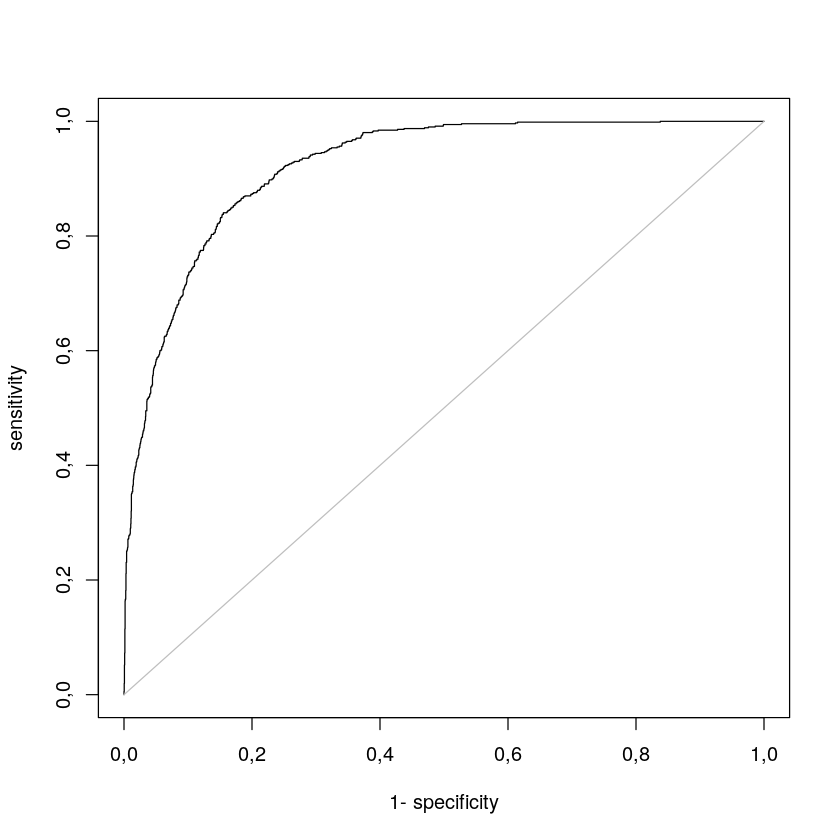

```r
# Curva ROC glm
library("AUC")

roc <- roc(out.test.rain, as.factor(df.glm.test.rain[,n.pca+1]))
auc(roc)
plot(roc)
```

[output not shown]

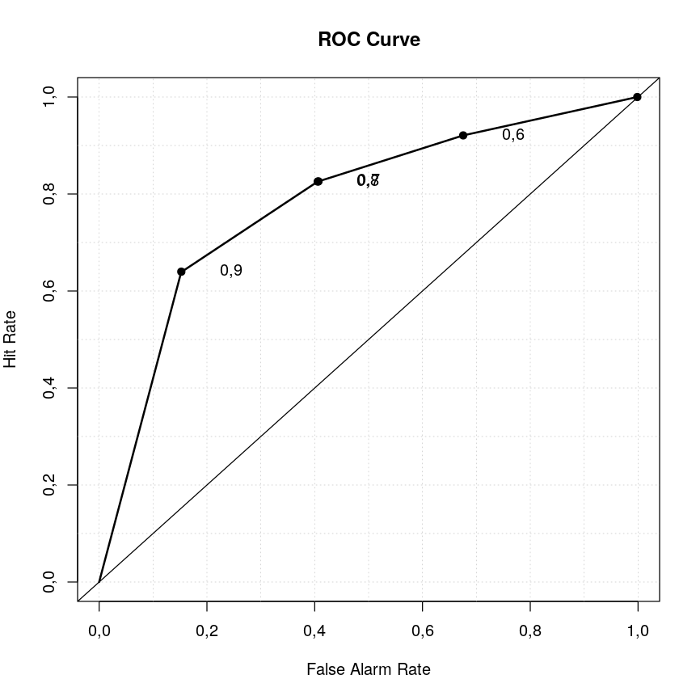

```r
# Curva ROC knn

library(verification)

n.pca = 10
ka = 7

pred <- knn(train = meteo.pca.calib$x[,1:n.pca],
            test = meteo.pca.test[,1:n.pca],
            cl = meteo.calib$rain,
            prob = TRUE,
            k = ka)

roc.plot(df.glm.test.rain$rain == 0,
               attr(pred, "prob"))
```

En el caso de lluvia, la curva ROC del método glm tiene más area por debajo, sugeriendo que la regresión lineal funciona, en general, mejor.

#### Lluvia fuerte

```r
n.pca = 4

# defino el data.frame de entrenamiento
df.glm.train <- meteo.pca.calib$x[,1:n.pca]
df.glm.train <- data.frame(df.glm.train, meteo.calib$heavy.rain)
names(df.glm.train) = c("PC1","PC2","PC3","PC4","heavy.rain")

# entreno el modelo
logistic.regr <- glm(df.glm.train$heavy.rain~., data = df.glm.train, family = binomial(link = "logit"))
```

```
[1] "Accuracy sobre el datset de train:"
```

97,4109589041096

```
[1] "Días con lluvia fuerte (1) y sin lluvia fuerte (0) en el dataset de entrenamiento:"
```

```
   0    1
7113  187
```

```
[1] "Matriz de confusión de entrenamiento:"
```

```
   out.bin.train
       0    1
  0 7109    4
  1  185    2
```

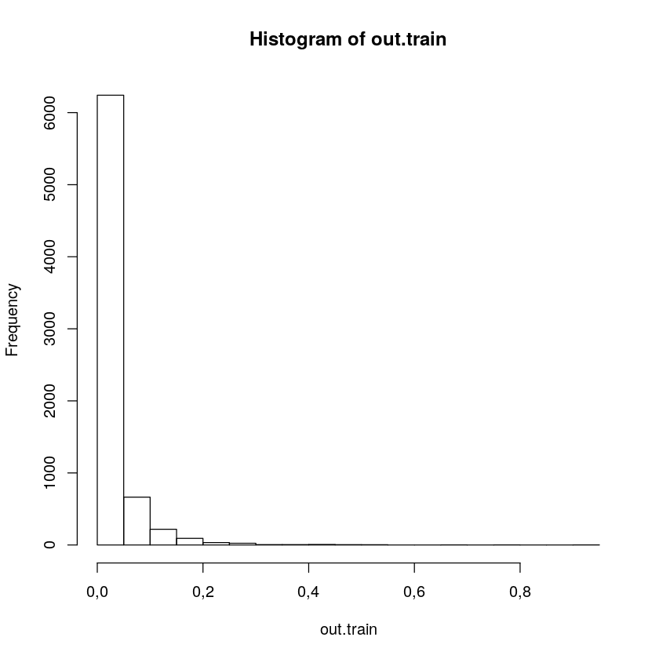

```r
# Tasa de acierto (Train)
out.train <- logistic.regr$fitted.values
out.bin.train <- as.double(out.train > 0.5)
print("Accuracy sobre el datset de train:")
100*sum(diag(table(df.glm.train[,n.pca+1], out.bin.train))) / length(out.bin.train)

# Histograma de salida del modelo
hist(out.train)

print(paste("Días con lluvia fuerte (1) y sin lluvia fuerte (0) en el dataset de entrenamiento:"))
table(meteo.calib$heavy.rain)

# Matriz de confusión de entrenamiento
print("Matriz de confusión de entrenamiento:")
table(meteo.calib$heavy.rain, out.bin.train)
```

```r
# defino el data.frame de test
df.glm.test <- meteo.pca.test[,1:n.pca]
df.glm.test <- data.frame(df.glm.test, meteo.test$heavy.rain)
names(df.glm.test) = c("PC1","PC2","PC3","PC4","heavy.rain")

# Tasa de acierto (test)
out.test <- predict(object = logistic.regr, newdata = df.glm.test);
out.bin.test <- as.double(out.test > 0.5)
print("Accuracy sobre el datset de test:")
100*sum(diag(table(df.glm.test[,n.pca+1], out.bin.test))) / length(out.bin.test)

# Histograma de salida del modelo
#hist(out.test)

print(paste("Días con lluvia fuerte (1) y sin lluvia fuerte (0) en el dataset de test:"))
table(meteo.test$heavy.rain)

# Matriz de confusión de test
print("Matriz de confusión de test:")
table(meteo.test$heavy.rain, out.bin.test)
```

```
[1] "Accuracy sobre el datset de test:"
```

97,4302897758338

```
[1] "Días con lluvia fuerte (1) y sin lluvia fuerte (0) en el dataset de test:"
```

```
   0    1
3565   93
```

```
[1] "Matriz de confusión de test:"
```

```
   out.bin.test
       0    1
  0 3564    1
  1   93    0
```

Tanto en la muestra de entrenamiento como en la muestra de test, el método de regresión lineal parece funcionar de la misma manera: básicamente predice que nunca va a haber lluvia fuerte. La razón es un poco la misma que en el caso KNN: la gran mayoría de los días no presentan lluvia mayor a 20mm, de manera que el método no logra entender verdaderamente como identificarlos. Por otro lado, prediciendo que nunca hay lluvia, la accuracy es muy alta y la previsión es (aparentemente) generalizable, ya que tanto en el dataset de entrenamiento como en el de test es del 97%. Este dato, obviamente, es engañoso, ya que tiene en cuenta solo la diagonal de la matriz de confusión. Mirando por ejemplo a la matriz de confusión del dataset de test, se nota que todos los días de lluvia fuerte han sido clasificados como días sin lluvia fuerte (falsos negativos) y que no hay ni un día de lluvia fuerte clasificado como tal (los verdaderos positivos son cero).

0,862401785579645

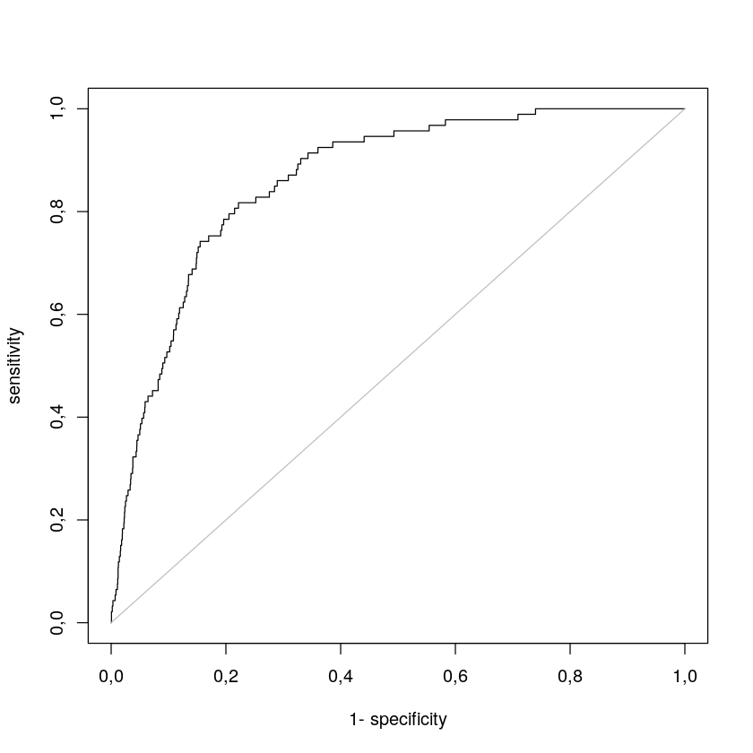

```r
# Curva ROC glm
library("AUC")

roc <- roc(out.test, as.factor(df.glm.test[,n.pca+1]))
auc(roc)
plot(roc)
```

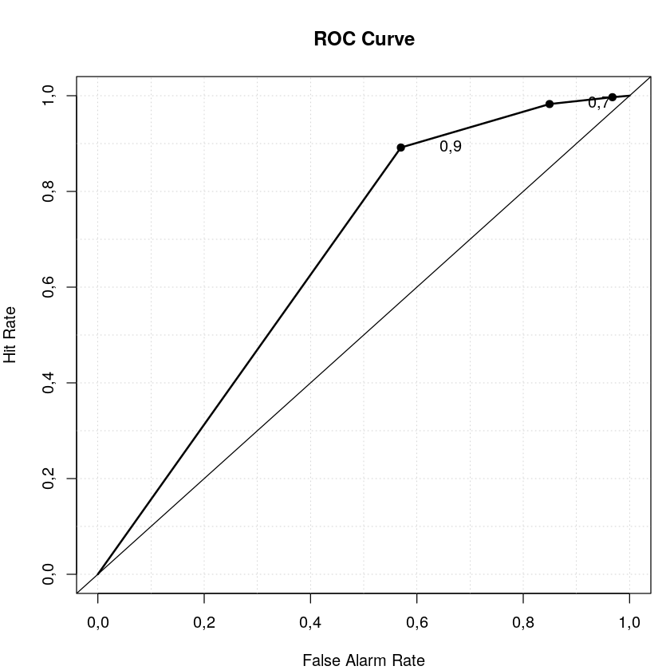

```r
# Curva ROC knn

library(verification)

n.pca = 4
ka = 7

pred <- knn(train = meteo.pca.calib$x[,1:n.pca],
            test = meteo.pca.test[,1:n.pca],
            cl = meteo.calib$heavy.rain,
            prob = TRUE,
            k = ka)

roc.plot(df.glm.test$heavy.rain == 0,
               attr(pred, "prob"))
```

En este caso especifico, ninguno de los dos métodos es capaz de predecir de manera eficaz los días de lluvia fuerte.